# 基本统计描述

数据分析的两大抓手是统计分析和图形显示，所以进行数据分析以前需了解一下R语言中这两类函数。

## 一、基本图像显示函数

R中的绘图命令可以分为“高水平”、“低水平”和“交互式”三中绘图命令。

> - “高水平”绘图命令可以在图形设备上绘制新图
> - “低水平”绘图命令将在已经存在的图形上添加更多的绘图信息，如点、线、多边形等
> - “交互式”绘图命令创建的绘图，可以使用如鼠标这类的定点装置来添加活提取绘图信息。

### 1.1 R语言中的高级绘图函数

#### 1.1.1 常见函数

> - plot(x)
> - barplot(x)
> - pie(x)
> - hist(x)
> - qqnorm(x)
> - dotchart(x)
> - boxplot(x)
> - plot(x,y)
> - matplot(x,y)
> - pairs(x)
> - stripchart(x)
> - coplot(x)
> - symbols(x,y,…)
> - contour(x,y,z)
> - image(x,y,z)
> - persp(x,y,z) 三围透视图

#### 1.1.2 常用属性

**type=“p”,指定图形的类型。**

> - “p”:点
> - “l”:线
> - “b”:点连线
> - “o”:线在点上的连线
> - “h”:垂直线
> - “s”:阶梯式，垂直线顶端显示数据
> - “S”:阶梯式，垂直先底端显示数据

**xlim=,ylim=指定轴的上下限**

**xlab=,ylab=坐标轴的标签，必须是字符型值**

**main=主标题,必须是字符星值**

**sub=副标题**

**add=FALSE如果是TRUE,叠加图形到前一个图上**

**axes=TRUE如果是FALSE,不会绘制轴与边框**

下面以学生身高及其分组数据来对这些函数做些简单介绍。

```r
#源数据读取
UG = read.csv("resources/UnderGraduate.csv",header=T,fileEncoding="gbk")
head(UG)
```

```
##          id name sex region      birth income height weight score
## 1 201205A01 赵**  女   东部   1992-4-8   16.6    164     66  64.1
## 2 201205A02 高**  男   西部  1993-5-12   20.6    162     65  71.2
## 3 201205A03 朱**  男   中部  1995-7-18    4.1    186     87  90.2
## 4 201205A04 许**  女   中部   1995-1-8   78.8    165     67  74.9
## 5 201205A05 陈**  男   西部   1992-3-7    3.8    165     69  75.6
## 6 201205A06 吴**  男   东部 1995-11-27   14.8    187     89  92.1
```

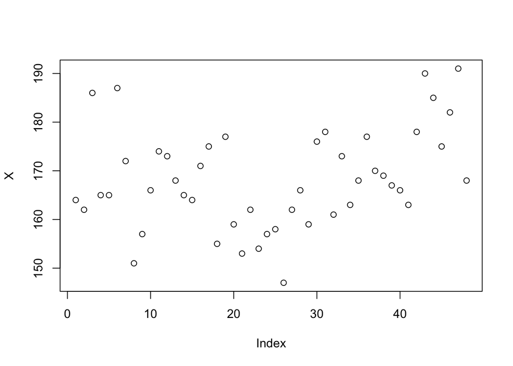

```r
X <- UG$height
plot(X)  #plot(X,type='p')
```

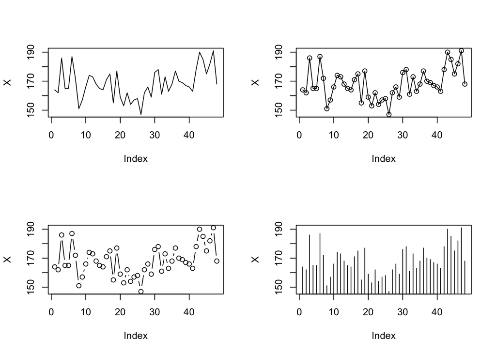

```r
oldpar <- par(mfcol=c(2,2))
plot(X,type='l')
plot(X,type='b')
plot(X,type='o')
plot(X,type='h')
```

```r
par(oldpar)
```

##### (2) 图形修饰：xlab,ylab,ylim,main。

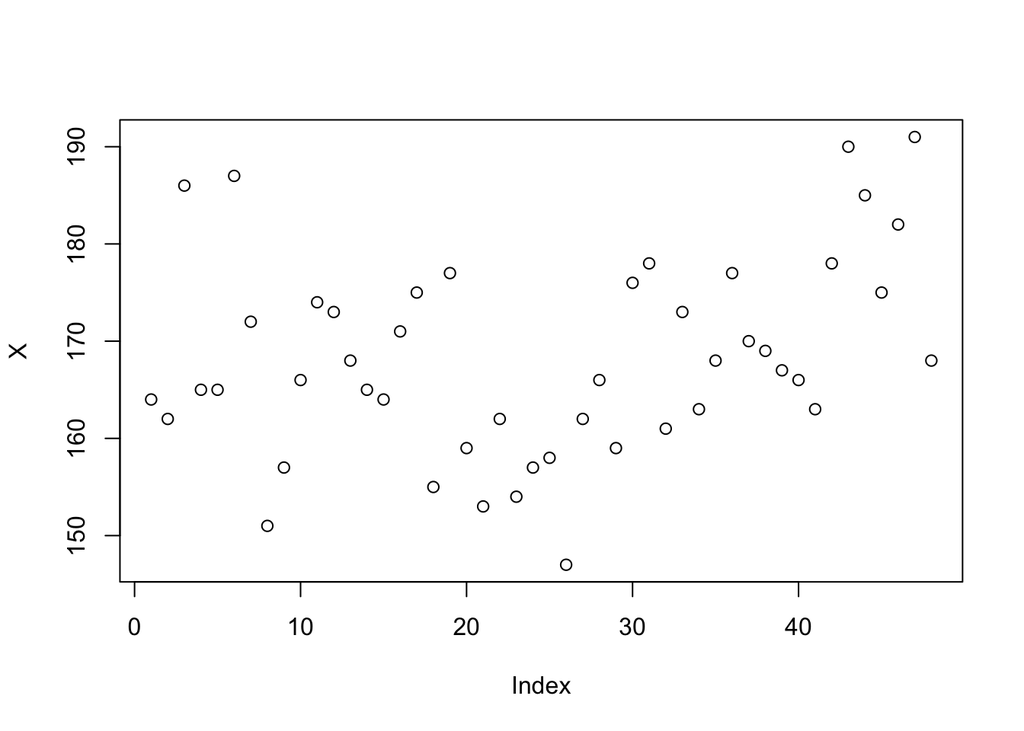

```r
plot(X)
```

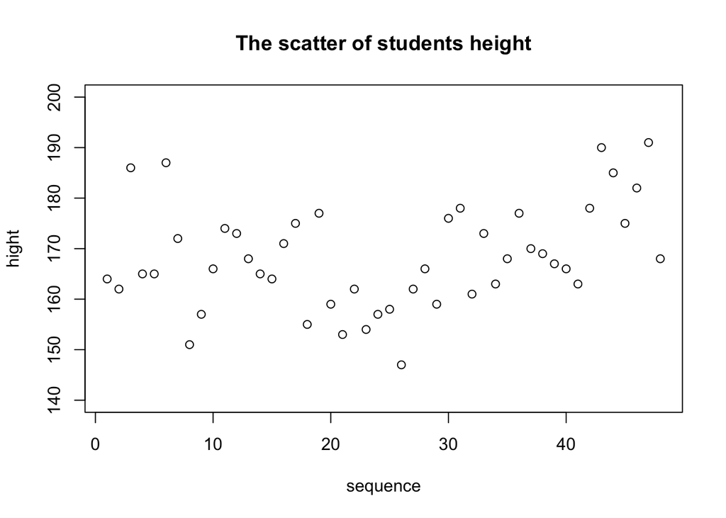

```r
plot(X,xlab='sequence',ylab='hight',ylim=c(140,200),main='The scatter of students height')
```